# Aim1_Analysis_v4

Lindsay Kephart

11/13/2023

## Summary

### Overview of this document

This HTML page provides information about Aim 1, including

- Study objectives
- Definitions and descriptive statistics for the (a) outcome variables and (b) independent variables/covariates
- Example maps made using R studio to demonstrate the distribution of cannabis outlets in a few legalized states
- Unadjusted and adjusted multilevel model results examining the relationship between the 4 outcomes and each covariate.

### Aim 1: Study Objectives

1. Compare community characteristics among census tracts with and without RCDs in states that have legalized retail sales of recreational cannabis.
2. Describe the association between RCD locations and community characteristics on the census tract level.
   - Use unadjusted & adjusted multilevel models to identify statistically significant correlates of RCD counts and measures of RCD density.
3. Use spatial statistics (e.g., Morans I) to identify the extent census tracts are more closely correlated with their neighbor tracts.

## Data Overview

The two tabs below describe the outcome variables and the independent variables for analysis.

### Outcome variables

Outcome variables include:

- Whether or not a census tract has a dispensary (1=at least one) or not (0) (can_bin)
- Count: the number of RCDs in a census tract (cannabis_count)
- Density per population: the number of RCDs per 1000 population (cdensitypop)
- Density per land area: the number of RCDs per square mile (cdensityland)
- Density per roadway: the number of RCDS per 10 km of roadway (cdensityroad)

#### Descriptive Statistics

The following table shows descriptive statistics for the outcomes.

Summary Statistics

| Variable | N | Mean | Std. Dev. | Min | Pctl. 25 | Pctl. 75 | Max |
| --- | --- | --- | --- | --- | --- | --- | --- |
| can_bin | 30225 | 0.11 | 0.31 | 0 | 0 | 0 | 1 |
| cannabis_count | 30225 | 0.18 | 0.7 | 0 | 0 | 0 | 25 |
| cdensitypop | 30221 | 0.054 | 0.23 | 0 | 0 | 0 | 8.4 |
| cdensityland | 30217 | 0.21 | 1.2 | 0 | 0 | 0 | 28 |
| cdensityroad | 21209 | 0.35 | 1.9 | 0 | 0 | 0 | 62 |

#### Plots

The following charts are box plots showing the spread and frequency of the outcome data. There are n=3341 census tract with any dispensaries and n=26884 census tracts with no dispensaries. Therefore, zero is the most frequent value.

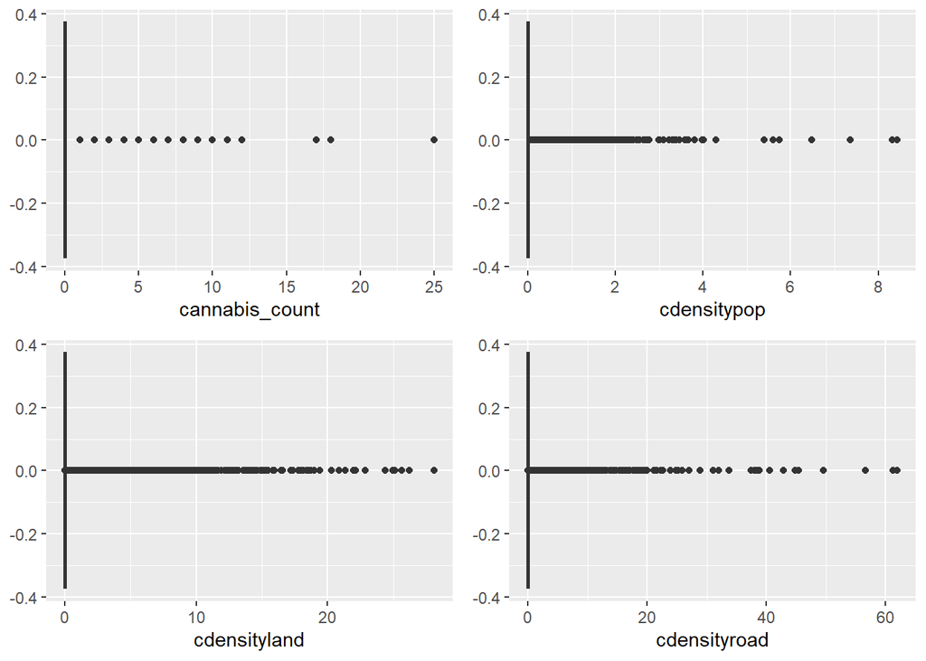

### Independent Variables

Below you will find definitions and summary statistics for all the independent variables / census tract characteristics considered for this analysis organized by broad category. All sociodemographic data was obtained from the the American Community Survey 2017-2021 5-year estimates.

Sociodemographics

- Age: percent of census tract population under 18 years of age (percent_under18)
- Gender: percent of census tract population that is female (percent_female)
- Non-Hispanic (NH) White: percent of NH census tract population that identify as white (percent_white)
- Non-Hispanic (NH) Black: percent of NH census tract population that identify as Black (percent_black)
- Hispanic: percent of census tract population that identify as Hispanic (percent_hispanic)
- Proportion non-white: percent of census tract population that identifies as a race or ethnicity other than NH, white (percent_nonwhite)

Summary Statistics

| Variable | N | Mean | Std. Dev. | Min | Pctl. 25 | Pctl. 75 | Max |
| --- | --- | --- | --- | --- | --- | --- | --- |
| total_pop | 30225 | 4072 | 1643 | 3 | 2895 | 5106 | 38223 |
| POPDENS | 23038 | 5879 | 8783 | 0 | 889 | 7270 | 508698 |
| LAND_AREA | 23537 | 61 | 898 | 0.004 | 0.51 | 4.6 | 85426 |
| percent_female | 30225 | 0.5 | 0.053 | 0 | 0.48 | 0.53 | 1 |
| percent_under18 | 30225 | 0.21 | 0.073 | 0 | 0.17 | 0.26 | 0.75 |
| percent_white | 30225 | 0.57 | 0.3 | 0 | 0.32 | 0.82 | 1 |
| percent_black | 30225 | 0.083 | 0.17 | 0 | 0.0049 | 0.076 | 1 |
| percent_hispanic | 30225 | 0.23 | 0.24 | 0 | 0.047 | 0.33 | 1 |
| percent_nonwhite | 30225 | 0.43 | 0.3 | 0 | 0.18 | 0.68 | 1 |

Measures of Deprivation or Privilege

*Income and Poverty*

- Median household income (med_hh_income) (scaled per $1000)
- Percent of households living under the federal poverty line (FPL) (pctpov)
- Proportion of the labor force that is currently unemployed (among population 16+)

*Education*

- Percent with less than a high school degree (among population 25+) (percent_lesshs)
- Percent with a bachelor’s college degree or more (among population 25+) (percent_bachelor)

*Household characteristics*

- Proportion of single parent households (percent_singlefamhouse)
- Proportion of households that speak/prefer a language other than English at home (percent_noteng)
- Percent of families receiving public assistance income in the past 12 months (percent_assist)

*Housing*

- Median home value (median_home_value) (scaled per $1000)
- Proportion of housing units that are renter-occupied (percent_renter)
- Proportion of housing units that are vacant (percent_vacant)
- Percent of housing units that have been rented/owned for 5 years or less

Summary Statistics

| Variable | N | Mean | Std. Dev. | Min | Pctl. 25 | Pctl. 75 | Max |
| --- | --- | --- | --- | --- | --- | --- | --- |
| med_hh_income | 29951 | 82 | 40 | 2.5 | 54 | 101 | 250 |
| pctpov | 30139 | 0.13 | 0.11 | 0 | 0.052 | 0.17 | 1 |
| percent_unemployed | 30225 | 0.36 | 0.11 | 0 | 0.3 | 0.42 | 1 |
| percent_highschool | 30214 | 0.88 | 0.11 | 0 | 0.84 | 0.96 | 1 |
| percent_lesshs | 30214 | 0.099 | 0.095 | 0 | 0.032 | 0.13 | 0.96 |
| percent_bachelor | 30214 | 0.35 | 0.21 | 0 | 0.18 | 0.49 | 1 |
| percent_singlefamhouse | 30122 | 0.18 | 0.1 | 0 | 0.1 | 0.23 | 1 |
| percent_notenglishonly | 30122 | 0.29 | 0.24 | 0 | 0.094 | 0.43 | 1 |
| percent_assistance | 30122 | 0.031 | 0.034 | 0 | 0.009 | 0.043 | 0.75 |
| median_home_value | 29462 | 405 | 320 | 10 | 194 | 511 | 2000 |
| percent_renter | 30127 | 0.34 | 0.22 | 0 | 0.15 | 0.49 | 1 |
| percent_vacant | 30127 | 0.096 | 0.11 | 0 | 0.033 | 0.12 | 1 |
| percent_renterowner2015 | 30127 | 0.35 | 0.14 | 0 | 0.25 | 0.43 | 1 |

*Measures of Segregation*

*Location Quotient*: a measure of concentration/clustering and presents the relative homogeneity of each census tract as compared to the overall MSA

- LQ_NH_White_Alone: the percent of non-Hispanic, white residents in the CT as compared to the percent of white residents within the overall MSA. A value of 1 indicate that the census tract has the same share of white residents as compared to the larger MSA. A LQ greater than 1 indicates a greater concentration of white residents compared to the larger MSA.
- LQ_Black_Alone: the percent of non-Hispanic, Black residents in the CT as compared to the percent of Black residents within the overall MSA. A value of 1 indicate that the census tract has the same share of Black residents as compared to the larger MSA. A LQ greater than 1 indicates a greater concentration of Blacks residents relative to the larger MSA.
- LQ_Hispanic: the percent of white residents in the CT as compared to the percent of white residents within the overall MSA. A value of 1 indicate that the census tract has the same share of white residents as compared to the larger MSA. A LQ greater than 1 indicates a greater concentration of white residents compared to the larger MSA.

- ICE_Black_Alone_White_Alone: The ICE race privilege group is non-Hispanic White people and the deprived group non-Hispanic Black people.
- ICE_Hispanic_NH_White_Alone: The ICE race privilege group is non-Hispanic White people and the deprived group Hispanic.

*Local Exposure and Isolation Index (LEx/Is)*: Measures the probability that two individuals living within a census tract of either different or the same racial/ethnic group(s) will interact. A value of 0 means that the chance of two people from different racial/ethnic groups interacting in a given census tract is equal to the expected probability if the MSA were perfectly mixed. Values greater than zero indicate that the interaction is more likely to occur within the census tract than in the MSA, and values less than zero indicate that it is less likely.

- Lex_Is_Black_Alone_White_Alone: LEX/Is for Black/White Interaction in the census tract
- Lex_Is_Hispanic_NH_White_Alone: LEX/Is for Hispanic/White Interaction in the census tract

Summary Statistics

| Variable | N | Mean | Std. Dev. | Min | Pctl. 25 | Pctl. 75 | Max |
| --- | --- | --- | --- | --- | --- | --- | --- |
| LQ_NH_White_Alone | 21472 | 1 | 0.52 | 0.01 | 0.72 | 1.3 | 6.4 |
| LQ_Black_Alone | 17105 | 1.3 | 1.6 | 0.02 | 0.27 | 1.7 | 20 |
| LQ_Hispanic | 20632 | 1.1 | 1.1 | 0.02 | 0.38 | 1.4 | 30 |
| ICE_Black_Alone_White_Alone | 17329 | -0.57 | 0.4 | -0.99 | -0.84 | -0.44 | 0.99 |
| ICE_Hispanic_NH_White_Alone | 21265 | -0.39 | 0.5 | -0.99 | -0.8 | -0.05 | 0.99 |
| Lex_Is_Black_Alone_White_Alone | 16938 | -0.26 | 0.48 | -2.2 | -0.59 | 0.11 | 1.4 |
| Lex_Is_Hispanic_NH_White_Alone | 20405 | -0.25 | 0.44 | -3.6 | -0.45 | 0.02 | 1 |

Environmental Characteristics

- Walkability score (AVGWALK): The National Walkability Index ranks census tracts according to their relative walkability. A greater value indicates greater walkability.

*Schools*

- School count: the total number of schools in a census tract (school_count)
- School binary variable: Whether a census tract has a school or not (school_bin)

*Parks*

- Park count: the total number of parks in a census tract (park_count)
- Proportion of census tract area that is park space (percent_parkarea)
- Park binary variable: Whether a census tract has a park or not (park_bin)

*Retailers*

- Business count: the total number of retail businesses in a census tract (business_count)
- Average retail sales amount ($) of retail business per census tract (mean_sales) (scaled per $ 100)
- Total number of retail sales amount ($) of retail businesses per census tract (sum_sales) (scaled per $1000)

Summary Statistics

| Variable | N | Mean | Std. Dev. | Min | Pctl. 25 | Pctl. 75 | Max |
| --- | --- | --- | --- | --- | --- | --- | --- |
| AVGWALK | 23552 | 10 | 2.8 | 1 | 8.4 | 12 | 19 |
| school_count | 30225 | 2.4 | 4.6 | 0 | 0 | 3 | 191 |
| school_bin | 30225 | 0.75 | 0.43 | 0 | 0 | 1 | 1 |
| park_count | 30225 | 2.6 | 3.6 | 0 | 0 | 3 | 95 |
| percent_parkarea | 30225 | 0.061 | 0.13 | 0 | 0 | 0.056 | 1.2 |
| park_bin | 30225 | 0.75 | 0.44 | 0 | 0 | 1 | 1 |
| business_count | 28124 | 145 | 108 | 0 | 63 | 199 | 500 |
| mean_sales | 30220 | 17 | 29 | 0 | 7.3 | 18 | 1433 |
| sum_sales | 30224 | 364 | 945 | 0 | 59 | 362 | 46987 |

## Map Examples

This section provides an example of simple maps created in R to demonstrate the distribution of cannabis dispensaries on census tract population maps.

### Washington

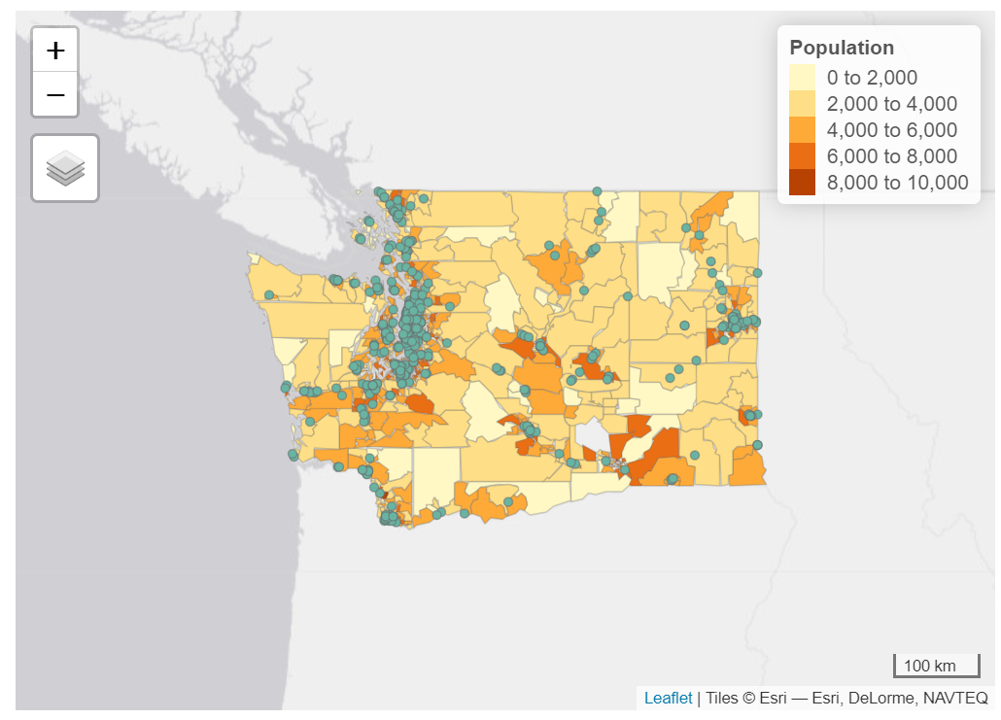

Washington

### Colorado

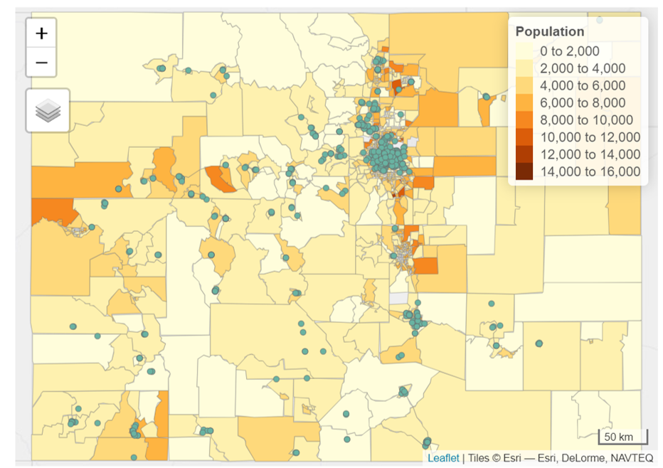

Colorado

### Oregon

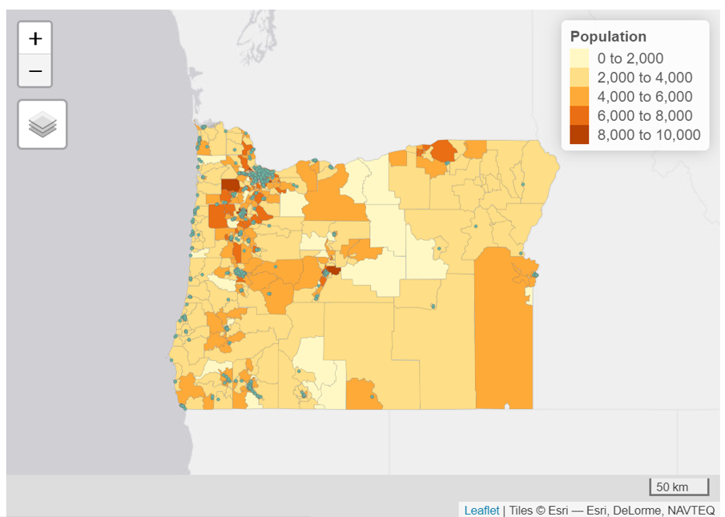

Oregon

## Unadjusted and Adjusted Results

- **Unadjusted models**: Univariate relationship between the covariate and the outcome
- **Adjusted model #1**: Covariates include population density, land area, urban/rural classification, U.S. Region
- **Adjusted model #2**: Covariates include % female, % under 18, % white, % black, % Hispanic, % below FPL, education (less HS, bachelors degree), unemployment, % receiving public assistance, % renters, % vacant units, Lex/Is BW, Lex/Is HW, walkability score, percent park area, # of schools

### RCD density per population

This table shows the unadjusted and adjusted regression results (beta estimate, 95% CI, and p-value) of each covariate on dispensary density per 1,000 population

| **Characteristic** | Unadjusted **Beta** | Unadjusted **95% CI**<sup>1</sup> | Unadjusted **p-value** | Adjusted 1 **Beta** | Adjusted 1 **95% CI**<sup>1</sup> | Adjusted 1 **p-value** | Adjusted 2 **Beta** | Adjusted 2 **95% CI**<sup>1</sup> | Adjusted 2 **p-value** |
| --- | --- | --- | --- | --- | --- | --- | --- | --- | --- |
| Demographics |  |  |  |  |  |  |  |  |  |
| Percent under 18 | -0.25 | -0.28, -0.21 | <0.001 | -0.22 | -0.27, -0.18 | <0.001 | -0.28 | -0.34, -0.23 | <0.001 |
| Percent female | -0.14 | -0.19, -0.09 | <0.001 | -0.12 | -0.18, -0.07 | <0.001 | -0.19 | -0.26, -0.12 | <0.001 |
| Percent White (NH) | 0.00 | -0.01, 0.01 | 0.92 | -0.02 | -0.03, -0.01 | 0.004 | 0.02 | -0.01, 0.05 | 0.21 |
| Percent Black (NH) | 0.00 | -0.01, 0.02 | 0.70 | 0.01 | 0.00, 0.03 | 0.13 | -0.04 | -0.08, 0.00 | 0.042 |
| Percent Hispanic | 0.02 | 0.00, 0.03 | 0.019 | 0.03 | 0.02, 0.05 | <0.001 | 0.00 | -0.04, 0.03 | 0.90 |
| Measures of Deprivation |  |  |  |  |  |  |  |  |  |
| Median Household Income | 0.00 | 0.00, 0.00 | <0.001 | 0.00 | 0.00, 0.00 | <0.001 | 0.00 | 0.00, 0.00 | 0.69 |
| Percent living under the FPL | 0.18 | 0.16, 0.21 | <0.001 | 0.20 | 0.18, 0.23 | <0.001 | 0.17 | 0.12, 0.22 | <0.001 |
| Percent unemployed | 0.01 | -0.01, 0.03 | 0.46 | -0.02 | -0.05, 0.01 | 0.14 | -0.11 | -0.15, -0.07 | <0.001 |
| Percent w/ less than a HS education | 0.07 | 0.04, 0.10 | <0.001 | 0.09 | 0.05, 0.12 | <0.001 | 0.11 | 0.03, 0.18 | 0.004 |
| Percent w/ a bachelor degree or more | -0.01 | -0.03, 0.00 | 0.049 | -0.01 | -0.03, 0.00 | 0.086 | 0.02 | 0.00, 0.05 | 0.10 |
| Percent of single-headed households | 0.00 | -0.03, 0.02 | 0.80 | 0.02 | -0.01, 0.05 | 0.22 | -0.02 | -0.07, 0.03 | 0.41 |
| Percent who speak a language other than English at home | -0.02 | -0.03, 0.00 | 0.019 | 0.00 | -0.02, 0.02 | 0.92 | -0.07 | -0.11, -0.03 | <0.001 |
| Percent recieving public assistance | 0.32 | 0.24, 0.40 | <0.001 | 0.40 | 0.31, 0.49 | <0.001 | 0.19 | 0.07, 0.30 | 0.001 |
| Housing |  |  |  |  |  |  |  |  |  |
| Median Home Value | 0.00 | 0.00, 0.00 | 0.002 | 0.00 | 0.00, 0.00 | 0.009 | 0.00 | 0.00, 0.00 | 0.10 |
| % of homes that are renter occupied | 0.09 | 0.08, 0.11 | <0.001 | 0.14 | 0.13, 0.16 | <0.001 | 0.05 | 0.03, 0.08 | <0.001 |
| % of homes that are vacant | 0.17 | 0.14, 0.19 | <0.001 | 0.15 | 0.12, 0.18 | <0.001 | 0.15 | 0.10, 0.20 | <0.001 |
| % of homes rented/owned for 5 years or less | 0.09 | 0.07, 0.11 | <0.001 | 0.15 | 0.13, 0.18 | <0.001 | -0.01 | -0.05, 0.03 | 0.61 |
| Measures of Segregation |  |  |  |  |  |  |  |  |  |
| LQ: White Alone | -0.01 | -0.01, 0.00 | 0.004 | -0.01 | -0.02, 0.00 | <0.001 | 0.01 | -0.01, 0.02 | 0.32 |
| LQ: Black Alone | 0.00 | 0.00, 0.01 | <0.001 | 0.00 | 0.00, 0.01 | <0.001 | 0.01 | 0.00, 0.01 | <0.001 |
| LQ: Hispanic Alone | 0.01 | 0.00, 0.01 | <0.001 | 0.01 | 0.00, 0.01 | <0.001 | 0.00 | -0.01, 0.00 | 0.76 |
| ICE: Black-White | 0.00 | -0.01, 0.00 | 0.37 | 0.00 | -0.01, 0.01 | 0.76 | -0.04 | -0.06, -0.01 | 0.006 |
| ICE: Hispanic-White | 0.01 | 0.00, 0.02 | 0.002 | 0.02 | 0.01, 0.03 | <0.001 | 0.00 | -0.03, 0.02 | 0.81 |
| LEX: Black-White | 0.03 | 0.02, 0.04 | <0.001 | 0.03 | 0.02, 0.04 | <0.001 | 0.01 | 0.01, 0.02 | <0.001 |
| LEX: Hispanic-White | 0.02 | 0.01, 0.03 | <0.001 | 0.02 | 0.01, 0.02 | <0.001 | 0.00 | -0.01, 0.01 | 0.89 |
| Environmental Characteristics |  |  |  |  |  |  |  |  |  |
| Average Walkability Score | 0.00 | 0.00, 0.00 | 0.005 | 0.00 | 0.00, 0.00 | <0.001 | 0.00 | 0.00, 0.00 | 0.11 |
| Number of schools | 0.00 | 0.00, 0.00 | 0.090 | 0.00 | 0.00, 0.00 | <0.001 | 0.00 | 0.00, 0.00 | 0.77 |
| Number of parks | 0.00 | 0.00, 0.00 | <0.001 | 0.00 | 0.00, 0.00 | <0.001 | 0.00 | 0.00, 0.00 | <0.001 |
| % of census tract that is park space | 0.01 | -0.01, 0.03 | 0.51 | 0.00 | -0.03, 0.02 | 0.74 | -0.02 | -0.05, 0.01 | 0.19 |
| Total number of businesses | 0.00 | 0.00, 0.00 | <0.001 | 0.00 | 0.00, 0.00 | <0.001 | 0.00 | 0.00, 0.00 | <0.001 |
| Average sales per census tract | 0.00 | 0.00, 0.00 | <0.001 | 0.00 | 0.00, 0.00 | <0.001 | 0.00 | 0.00, 0.00 | <0.001 |
| Total sales per census tract | 0.00 | 0.00, 0.00 | <0.001 | 0.00 | 0.00, 0.00 | <0.001 | 0.00 | 0.00, 0.00 | <0.001 |

<sup>1</sup> CI = Confidence Interval

### RCD density per land area

This table shows the unadjusted and adjusted regression results (beta estimate, 95% CI, and p-value) of each covariate on dispensary density per square mile (land area)

| **Characteristic** | Unadjusted **Beta** | Unadjusted **95% CI**<sup>1</sup> | Unadjusted **p-value** | Adjusted 1 **Beta** | Adjusted 1 **95% CI**<sup>1</sup> | Adjusted 1 **p-value** | Adjusted 2 **Beta** | Adjusted 2 **95% CI**<sup>1</sup> | Adjusted 2 **p-value** |
| --- | --- | --- | --- | --- | --- | --- | --- | --- | --- |
| Demographics |  |  |  |  |  |  |  |  |  |
| Percent under 18 | -1.89 | -2.06, -1.71 | <0.001 | -1.45 | -1.65, -1.25 | <0.001 | -2.13 | -2.46, -1.81 | <0.001 |
| Percent female | -0.56 | -0.81, -0.32 | <0.001 | -0.61 | -0.88, -0.34 | <0.001 | -0.64 | -1.05, -0.23 | 0.002 |
| Percent White (NH) | -0.16 | -0.21, -0.11 | <0.001 | 0.06 | 0.00, 0.11 | 0.050 | 0.28 | 0.11, 0.45 | 0.001 |
| Percent Black (NH) | 0.19 | 0.11, 0.27 | <0.001 | -0.01 | -0.09, 0.07 | 0.74 | 0.01 | -0.22, 0.24 | 0.93 |
| Percent Hispanic | 0.05 | -0.02, 0.11 | 0.14 | -0.07 | -0.14, 0.00 | 0.038 | -0.09 | -0.29, 0.10 | 0.35 |
| Measures of Deprivation |  |  |  |  |  |  |  |  |  |
| Median Household Income | 0.00 | 0.00, 0.00 | <0.001 | 0.00 | 0.00, 0.00 | <0.001 | 0.00 | 0.00, 0.00 | 0.56 |
| Percent living under the FPL | 1.00 | 0.88, 1.13 | <0.001 | 0.72 | 0.58, 0.85 | <0.001 | 0.94 | 0.67, 1.21 | <0.001 |
| Percent unemployed | -0.99 | -1.12, -0.87 | <0.001 | -0.53 | -0.67, -0.39 | <0.001 | -1.25 | -1.49, -1.01 | <0.001 |
| Percent w/ less than a HS education | 0.24 | 0.10, 0.38 | <0.001 | 0.10 | -0.06, 0.25 | 0.21 | 1.27 | 0.87, 1.67 | <0.001 |
| Percent w/ a bachelor degree or more | 0.35 | 0.29, 0.42 | <0.001 | 0.15 | 0.08, 0.22 | <0.001 | 0.42 | 0.27, 0.56 | <0.001 |
| Percent of single-headed households | -0.16 | -0.28, -0.03 | 0.015 | -0.31 | -0.44, -0.18 | <0.001 | -0.35 | -0.65, -0.06 | 0.019 |
| Percent who speak a language other than English at home | 0.18 | 0.11, 0.25 | <0.001 | -0.12 | -0.20, -0.05 | 0.001 | -0.29 | -0.50, -0.08 | 0.008 |
| Percent recieving public assistance | 1.52 | 1.12, 1.91 | <0.001 | 1.12 | 0.69, 1.55 | <0.001 | 0.82 | 0.19, 1.45 | 0.011 |
| Housing |  |  |  |  |  |  |  |  |  |
| Median Home Value | 0.00 | 0.00, 0.00 | <0.001 | 0.00 | 0.00, 0.00 | 0.009 | 0.00 | 0.00, 0.00 | <0.001 |
| % of homes that are renter occupied | 1.00 | 0.94, 1.06 | <0.001 | 0.70 | 0.62, 0.77 | <0.001 | 0.34 | 0.21, 0.46 | <0.001 |
| % of homes that are vacant | 0.03 | -0.09, 0.15 | 0.61 | 0.34 | 0.19, 0.49 | <0.001 | 0.51 | 0.21, 0.80 | <0.001 |
| % of homes rented/owned for 5 years or less | 1.12 | 1.03, 1.22 | <0.001 | 0.79 | 0.67, 0.90 | <0.001 | -0.28 | -0.51, -0.04 | 0.020 |
| Measures of Segregation |  |  |  |  |  |  |  |  |  |
| LQ: White Alone | -0.09 | -0.11, -0.06 | <0.001 | 0.01 | -0.02, 0.04 | 0.47 | 0.05 | -0.02, 0.12 | 0.17 |
| LQ: Black Alone | 0.02 | 0.01, 0.03 | <0.001 | 0.01 | 0.00, 0.02 | 0.013 | 0.03 | 0.01, 0.05 | 0.010 |
| LQ: Hispanic Alone | 0.04 | 0.03, 0.06 | <0.001 | 0.01 | 0.00, 0.03 | 0.078 | 0.00 | -0.02, 0.03 | 0.81 |
| ICE: Black-White | 0.09 | 0.04, 0.13 | <0.001 | -0.02 | -0.07, 0.02 | 0.31 | -0.06 | -0.20, 0.08 | 0.42 |
| ICE: Hispanic-White | 0.14 | 0.10, 0.17 | <0.001 | -0.01 | -0.05, 0.02 | 0.51 | 0.04 | -0.09, 0.17 | 0.58 |
| LEX: Black-White | 0.12 | 0.08, 0.16 | <0.001 | 0.12 | 0.08, 0.15 | <0.001 | 0.05 | 0.01, 0.10 | 0.024 |
| LEX: Hispanic-White | 0.04 | 0.01, 0.08 | 0.020 | 0.07 | 0.04, 0.10 | <0.001 | 0.00 | -0.06, 0.05 | 0.87 |
| Environmental Characteristics |  |  |  |  |  |  |  |  |  |
| Average Walkability Score | 0.04 | 0.03, 0.04 | <0.001 | 0.02 | 0.01, 0.02 | <0.001 | 0.01 | 0.00, 0.01 | 0.061 |
| Number of schools | -0.01 | -0.01, 0.00 | <0.001 | 0.00 | 0.00, 0.00 | 0.49 | 0.00 | -0.01, 0.01 | 0.57 |
| Number of parks | -0.01 | -0.01, -0.01 | <0.001 | 0.00 | -0.01, 0.00 | 0.21 | 0.00 | -0.01, 0.00 | 0.57 |
| % of census tract that is park space | -0.47 | -0.58, -0.37 | <0.001 | -0.25 | -0.36, -0.13 | <0.001 | -0.43 | -0.61, -0.25 | <0.001 |
| Total number of businesses | 0.00 | 0.00, 0.00 | <0.001 | 0.00 | 0.00, 0.00 | <0.001 | 0.00 | 0.00, 0.00 | <0.001 |
| Average sales per census tract | 0.00 | 0.00, 0.00 | 0.73 | 0.00 | 0.00, 0.00 | 0.027 | 0.00 | 0.00, 0.00 | 0.26 |
| Total sales per census tract | 0.00 | 0.00, 0.00 | <0.001 | 0.00 | 0.00, 0.00 | <0.001 | 0.00 | 0.00, 0.00 | <0.001 |

<sup>1</sup> CI = Confidence Interval

### RCD density per roadway

This table shows the unadjusted and adjusted regression results (beta estimate, 95% CI, and p-value) of each covariate on dispensary density per 10 km of roadway

| **Characteristic** | Unadjusted **Beta** | Unadjusted **95% CI**<sup>1</sup> | Unadjusted **p-value** | Adjusted 1 **Beta** | Adjusted 1 **95% CI**<sup>1</sup> | Adjusted 1 **p-value** | Adjusted 2 **Beta** | Adjusted 2 **95% CI**<sup>1</sup> | Adjusted 2 **p-value** |
| --- | --- | --- | --- | --- | --- | --- | --- | --- | --- |
| Demographics |  |  |  |  |  |  |  |  |  |
| Percent under 18 | -1.40 | -1.76, -1.04 | <0.001 | -1.18 | -1.59, -0.77 | <0.001 | -1.87 | -2.54, -1.20 | <0.001 |
| Percent female | 0.08 | -0.40, 0.56 | 0.75 | -0.07 | -0.61, 0.46 | 0.79 | -0.08 | -0.90, 0.74 | 0.85 |
| Percent White (NH) | -0.27 | -0.37, -0.17 | <0.001 | -0.02 | -0.14, 0.10 | 0.76 | 0.16 | -0.21, 0.53 | 0.39 |
| Percent Black (NH) | 0.26 | 0.09, 0.43 | 0.003 | -0.08 | -0.25, 0.09 | 0.38 | -0.27 | -0.76, 0.21 | 0.27 |
| Percent Hispanic | 0.17 | 0.03, 0.30 | 0.014 | 0.08 | -0.08, 0.23 | 0.33 | -0.05 | -0.47, 0.38 | 0.83 |
| Measures of Deprivation |  |  |  |  |  |  |  |  |  |
| Median Household Income | 0.00 | 0.00, 0.00 | <0.001 | 0.00 | 0.00, 0.00 | <0.001 | 0.00 | 0.00, 0.00 | 0.34 |
| Percent living under the FPL | 1.05 | 0.80, 1.30 | <0.001 | 0.97 | 0.69, 1.24 | <0.001 | 1.00 | 0.44, 1.56 | <0.001 |
| Percent unemployed | -1.21 | -1.45, -0.97 | <0.001 | -0.68 | -0.97, -0.40 | <0.001 | -1.24 | -1.73, -0.75 | <0.001 |
| Percent w/ less than a HS education | 0.26 | -0.03, 0.55 | 0.080 | 0.22 | -0.11, 0.55 | 0.19 | 1.05 | 0.20, 1.89 | 0.015 |
| Percent w/ a bachelor degree or more | 0.35 | 0.22, 0.48 | <0.001 | 0.12 | -0.02, 0.26 | 0.088 | 0.50 | 0.21, 0.80 | <0.001 |
| Percent of single-headed households | 0.31 | 0.05, 0.57 | 0.018 | -0.09 | -0.37, 0.20 | 0.56 | -0.10 | -0.71, 0.51 | 0.75 |
| Percent who speak a language other than English at home | 0.21 | 0.08, 0.35 | 0.002 | -0.08 | -0.25, 0.08 | 0.32 | -0.71 | -1.16, -0.27 | 0.002 |
| Percent recieving public assistance | 2.21 | 1.42, 3.00 | <0.001 | 1.83 | 0.95, 2.72 | <0.001 | 1.03 | -0.27, 2.34 | 0.12 |
| Housing |  |  |  |  |  |  |  |  |  |
| Median Home Value | 0.00 | 0.00, 0.00 | 0.030 | 0.00 | 0.00, 0.00 | 0.029 | 0.00 | 0.00, 0.00 | 0.20 |
| % of homes that are renter occupied | 1.09 | 0.97, 1.21 | <0.001 | 0.88 | 0.73, 1.04 | <0.001 | 0.38 | 0.11, 0.65 | 0.005 |
| % of homes that are vacant | -0.40 | -0.62, -0.17 | <0.001 | 0.17 | -0.12, 0.46 | 0.25 | 0.31 | -0.29, 0.91 | 0.31 |
| % of homes rented/owned for 5 years or less | 1.33 | 1.15, 1.52 | <0.001 | 1.15 | 0.91, 1.39 | <0.001 | 0.09 | -0.40, 0.57 | 0.73 |
| Measures of Segregation |  |  |  |  |  |  |  |  |  |
| LQ: White Alone | -0.12 | -0.18, -0.06 | <0.001 | -0.02 | -0.08, 0.04 | 0.56 | 0.10 | -0.04, 0.24 | 0.16 |
| LQ: Black Alone | 0.03 | 0.01, 0.06 | 0.003 | 0.02 | 0.00, 0.05 | 0.051 | 0.06 | 0.01, 0.11 | 0.009 |
| LQ: Hispanic Alone | 0.06 | 0.03, 0.08 | <0.001 | 0.03 | 0.00, 0.05 | 0.061 | -0.03 | -0.08, 0.02 | 0.27 |
| ICE: Black-White | 0.07 | -0.03, 0.16 | 0.16 | -0.07 | -0.16, 0.03 | 0.18 | -0.13 | -0.43, 0.16 | 0.38 |
| ICE: Hispanic-White | 0.22 | 0.14, 0.29 | <0.001 | 0.05 | -0.03, 0.13 | 0.24 | -0.10 | -0.38, 0.17 | 0.46 |
| LEX: Black-White | 0.20 | 0.12, 0.27 | <0.001 | 0.19 | 0.11, 0.26 | <0.001 | 0.13 | 0.03, 0.22 | 0.008 |
| LEX: Hispanic-White | 0.16 | 0.08, 0.23 | <0.001 | 0.16 | 0.09, 0.24 | <0.001 | 0.04 | -0.06, 0.15 | 0.44 |
| Environmental Characteristics |  |  |  |  |  |  |  |  |  |
| Average Walkability Score | 0.05 | 0.04, 0.06 | <0.001 | 0.03 | 0.02, 0.04 | <0.001 | 0.01 | 0.00, 0.03 | 0.060 |
| Number of schools | -0.01 | -0.01, 0.00 | 0.001 | 0.00 | 0.00, 0.01 | 0.59 | 0.00 | -0.01, 0.02 | 0.53 |
| Number of parks | 0.00 | -0.01, 0.00 | 0.49 | 0.00 | -0.01, 0.01 | 0.70 | 0.00 | -0.01, 0.01 | 0.78 |
| % of census tract that is park space | -0.54 | -0.73, -0.36 | <0.001 | -0.35 | -0.56, -0.14 | 0.001 | -0.52 | -0.88, -0.16 | 0.004 |
| Total number of businesses | 0.00 | 0.00, 0.00 | <0.001 | 0.00 | 0.00, 0.00 | <0.001 | 0.00 | 0.00, 0.00 | <0.001 |
| Average sales per census tract | 0.00 | 0.00, 0.00 | 0.62 | 0.00 | 0.00, 0.00 | 0.14 | 0.00 | 0.00, 0.00 | 0.52 |
| Total sales per census tract | 0.00 | 0.00, 0.00 | <0.001 | 0.00 | 0.00, 0.00 | <0.001 | 0.00 | 0.00, 0.00 | 0.003 |

<sup>1</sup> CI = Confidence Interval

### Count (Negative Binomial)

This table shows the unadjusted and adjusted regression results (incidence rate ratio (IRR), 95% CI, and p-value) of each covariate on the number of dispensaries per census tract population.

| **Characteristic** | Unadjusted **exp(Beta)** | Unadjusted **95% CI**<sup>1</sup> | Unadjusted **p-value** | Adjusted 1 **exp(Beta)** | Adjusted 1 **95% CI**<sup>1</sup> | Adjusted 1 **p-value** | Adjusted 2 **exp(Beta)** | Adjusted 2 **95% CI**<sup>1</sup> | Adjusted 2 **p-value** |
| --- | --- | --- | --- | --- | --- | --- | --- | --- | --- |
| Demographics |  |  |  |  |  |  |  |  |  |
| Percent under 18 | 0.01 | 0.01, 0.02 | <0.001 | 0.01 | 0.01, 0.02 | <0.001 | 0.00 | 0.00, 0.01 | <0.001 |
| Percent female | 0.08 | 0.04, 0.17 | <0.001 | 0.09 | 0.04, 0.22 | <0.001 | 0.43 | 0.14, 1.30 | 0.13 |
| Percent White (NH) | 1.12 | 0.94, 1.32 | 0.21 | 0.76 | 0.61, 0.93 | 0.008 | 2.53 | 1.44, 4.47 | 0.001 |
| Percent Black (NH) | 1.06 | 0.79, 1.42 | 0.68 | 1.39 | 1.02, 1.91 | 0.039 | 0.59 | 0.27, 1.28 | 0.18 |
| Percent Hispanic | 1.32 | 1.08, 1.62 | 0.007 | 1.83 | 1.44, 2.33 | <0.001 | 1.25 | 0.66, 2.38 | 0.49 |
| Measures of Deprivation |  |  |  |  |  |  |  |  |  |
| Median Household Income | 0.99 | 0.98, 0.99 | <0.001 | 0.99 | 0.98, 0.99 | <0.001 | 0.99 | 0.99, 1.00 | <0.001 |
| Percent living under the FPL | 29.10 | 20.81, 40.72 | <0.001 | 44.06 | 28.98, 66.99 | <0.001 | 7.35 | 3.64, 14.82 | <0.001 |
| Percent unemployed | 0.90 | 0.61, 1.34 | 0.61 | 0.36 | 0.21, 0.60 | <0.001 | 0.06 | 0.03, 0.11 | <0.001 |
| Percent w/ less than a HS education | 3.84 | 2.52, 5.87 | <0.001 | 5.73 | 3.41, 9.65 | <0.001 | 12.36 | 3.88, 39.35 | <0.001 |
| Percent w/ a bachelor degree or more | 0.70 | 0.57, 0.86 | <0.001 | 0.70 | 0.55, 0.89 | 0.003 | 0.62 | 0.40, 0.96 | 0.031 |
| Percent of single-headed households | 0.97 | 0.65, 1.47 | 0.90 | 1.38 | 0.85, 2.24 | 0.20 | 1.29 | 0.53, 3.13 | 0.57 |
| Percent who speak a language other than English at home | 0.59 | 0.47, 0.73 | <0.001 | 0.85 | 0.64, 1.12 | 0.25 | 0.29 | 0.15, 0.56 | <0.001 |
| Percent recieving public assistance | 90.37 | 29.61, 275.76 | <0.001 | 356.79 | 92.17, 1,381.19 | <0.001 | 2.04 | 0.35, 11.84 | 0.42 |
| Housing |  |  |  |  |  |  |  |  |  |
| Median Home Value | 1.00 | 1.00, 1.00 | <0.001 | 1.00 | 1.00, 1.00 | <0.001 | 1.00 | 1.00, 1.00 | 0.38 |
| % of homes that are renter occupied | 6.66 | 5.57, 7.97 | <0.001 | 20.35 | 15.91, 26.04 | <0.001 | 4.28 | 2.94, 6.23 | <0.001 |
| % of homes that are vacant | 14.04 | 10.18, 19.35 | <0.001 | 13.56 | 8.59, 21.40 | <0.001 | 32.55 | 14.62, 72.48 | <0.001 |
| % of homes rented/owned for 5 years or less | 5.31 | 3.99, 7.07 | <0.001 | 21.18 | 14.59, 30.74 | <0.001 | 0.90 | 0.45, 1.80 | 0.76 |
| Measures of Segregation |  |  |  |  |  |  |  |  |  |
| LQ: White Alone | 0.85 | 0.77, 0.94 | 0.002 | 0.80 | 0.72, 0.89 | <0.001 | 0.98 | 0.80, 1.21 | 0.86 |
| LQ: Black Alone | 1.07 | 1.04, 1.10 | <0.001 | 1.07 | 1.04, 1.11 | <0.001 | 1.02 | 0.97, 1.09 | 0.44 |
| LQ: Hispanic Alone | 1.15 | 1.11, 1.20 | <0.001 | 1.17 | 1.12, 1.21 | <0.001 | 0.95 | 0.88, 1.02 | 0.15 |
| ICE: Black-White | 0.84 | 0.72, 0.99 | 0.033 | 0.98 | 0.84, 1.16 | 0.84 | 0.68 | 0.44, 1.05 | 0.082 |
| ICE: Hispanic-White | 1.19 | 1.06, 1.34 | 0.004 | 1.38 | 1.22, 1.57 | <0.001 | 0.99 | 0.67, 1.47 | 0.98 |
| LEX: Black-White | 1.85 | 1.64, 2.08 | <0.001 | 1.80 | 1.60, 2.03 | <0.001 | 1.33 | 1.17, 1.53 | <0.001 |
| LEX: Hispanic-White | 1.74 | 1.53, 1.99 | <0.001 | 1.68 | 1.47, 1.91 | <0.001 | 1.07 | 0.92, 1.26 | 0.38 |
| Environmental Characteristics |  |  |  |  |  |  |  |  |  |
| Average Walkability Score | 1.04 | 1.02, 1.06 | <0.001 | 1.09 | 1.07, 1.11 | <0.001 | 1.06 | 1.03, 1.08 | <0.001 |
| Number of schools | 0.99 | 0.98, 1.00 | 0.10 | 0.98 | 0.97, 0.99 | <0.001 | 1.00 | 0.98, 1.02 | 0.85 |
| Number of parks | 1.02 | 1.01, 1.03 | <0.001 | 1.02 | 1.00, 1.03 | 0.005 | 1.02 | 1.01, 1.04 | 0.004 |
| % of census tract that is park space | 1.14 | 0.84, 1.55 | 0.39 | 0.88 | 0.60, 1.28 | 0.49 | 0.54 | 0.30, 0.96 | 0.037 |
| Total number of businesses | 1.01 | 1.00, 1.01 | <0.001 | 1.00 | 1.00, 1.01 | <0.001 | 1.00 | 1.00, 1.00 | <0.001 |
| Average sales per census tract | 1.01 | 1.01, 1.01 | <0.001 | 1.01 | 1.01, 1.01 | <0.001 | 1.01 | 1.00, 1.01 | <0.001 |
| Total sales per census tract | 1.00 | 1.00, 1.00 | <0.001 | 1.00 | 1.00, 1.00 | <0.001 | 1.00 | 1.00, 1.00 | <0.001 |

<sup>1</sup> CI = Confidence Interval

## Summary of regression results

#### Summary table

The first two columns of the table list the variables that had an association with all 4 density outcomes and the last column lists all variables that were not associated with any density outcome after model adjustment.

[output not shown]

#### Key Highlights

- RCD density differs by census tract characteristics, in other words, density is not distributed across all community characteristics in the same way.
- The extent and direction of these associations differ depending on the measure used

## Census tract comparison (1 or more RCDs vs. No RCDs)

The following output compares census tract characteristics among census tracts with 1 or more dispensaries to census tracts with 0 dispensaries.

```
##
## --------Summary descriptives table by 'can_bin_head'---------
##
## ____________________________________________________________________________________________
##                                 1 or more dispensaries        No dispensaries      p.overall
##                                         N=3341                    N=26884
## ¯¯¯¯¯¯¯¯¯¯¯¯¯¯¯¯¯¯¯¯¯¯¯¯¯¯¯¯¯¯¯¯¯¯¯¯¯¯¯¯¯¯¯¯¯¯¯¯¯¯¯¯¯¯¯¯¯¯¯¯¯¯¯¯¯¯¯¯¯¯¯¯¯¯¯¯¯¯¯¯¯¯¯¯¯¯¯¯¯¯¯¯
## total_pop                      4058.15 [4004.29;4112.01] 4073.95 [4054.22;4093.68]   0.589
## POPDENS                        4697.21 [4428.60;4965.82] 6023.61 [5900.78;6146.45]  <0.001
## LAND_AREA                        85.45 [62.80;108.09]       58.51 [45.93;71.10]      0.042
## percent_female                     0.50 [0.50;0.50]          0.50 [0.50;0.50]       <0.001
## percent_under18                    0.20 [0.20;0.20]          0.22 [0.22;0.22]       <0.001
## percent_white                      0.61 [0.60;0.62]          0.56 [0.56;0.56]       <0.001
## percent_black                      0.06 [0.06;0.07]          0.09 [0.08;0.09]       <0.001
## percent_hispanic                   0.21 [0.21;0.22]          0.23 [0.23;0.23]        0.001
## percent_nonwhite                   0.39 [0.38;0.40]          0.44 [0.44;0.44]       <0.001
## med_hh_income                     68.65 [67.66;69.64]       83.68 [83.20;84.17]     <0.001
## pctpov                             0.15 [0.15;0.15]          0.12 [0.12;0.13]       <0.001
## percent_unemployed                 0.36 [0.36;0.37]          0.37 [0.36;0.37]        0.057
## percent_highschool                 0.88 [0.88;0.89]          0.88 [0.88;0.88]        0.514
## percent_lesshs                     0.10 [0.10;0.10]          0.10 [0.10;0.10]        0.932
## percent_bachelor                   0.33 [0.33;0.34]          0.35 [0.35;0.35]       <0.001
## percent_singlefamhouse             0.17 [0.17;0.17]          0.18 [0.18;0.18]       <0.001
## percent_singlefemalehouse          0.12 [0.12;0.12]          0.12 [0.12;0.12]       <0.001
## percent_notenglishonly             0.24 [0.24;0.25]          0.29 [0.29;0.30]       <0.001
## percent_assistance                 0.04 [0.04;0.04]          0.03 [0.03;0.03]       <0.001
## median_home_value               368.93 [359.37;378.48]    409.86 [405.94;413.79]    <0.001
## percent_renter                     0.39 [0.38;0.40]          0.33 [0.33;0.33]       <0.001
## percent_vacant                     0.11 [0.11;0.12]          0.09 [0.09;0.10]       <0.001
## percent_renterowner2015            0.38 [0.38;0.39]          0.34 [0.34;0.34]       <0.001
## LQ_NH_White_Alone                  0.97 [0.95;0.99]          1.03 [1.02;1.03]       <0.001
## LQ_Black_Alone                     1.51 [1.43;1.59]          1.30 [1.28;1.33]       <0.001
## LQ_Hispanic                        1.17 [1.13;1.22]          1.04 [1.03;1.06]       <0.001
## ICE_Black_Alone_White_Alone       -0.64 [-0.65;-0.62]       -0.56 [-0.57;-0.56]     <0.001
## ICE_Hispanic_NH_White_Alone       -0.43 [-0.45;-0.41]       -0.38 [-0.39;-0.37]     <0.001
## Lex_Is_Black_Alone_White_Alone    -0.11 [-0.13;-0.09]       -0.28 [-0.29;-0.27]     <0.001
## Lex_Is_Hispanic_NH_White_Alone    -0.15 [-0.17;-0.13]       -0.27 [-0.27;-0.26]     <0.001
## AVGWALK                           10.29 [10.18;10.39]       10.33 [10.29;10.37]      0.442
## school_count                       2.38 [2.26;2.50]          2.43 [2.37;2.49]        0.460
## school_bin                         0.76 [0.75;0.78]          0.75 [0.74;0.75]        0.032
## park_count                         3.18 [3.03;3.33]          2.48 [2.44;2.52]       <0.001
## percent_parkarea                   0.07 [0.06;0.07]          0.06 [0.06;0.06]        0.022
## park_bin                           0.80 [0.79;0.82]          0.74 [0.73;0.74]       <0.001
## business_count                  204.74 [200.40;209.08]    138.19 [136.89;139.48]    <0.001
## mean_sales                        18.62 [17.50;19.74]       16.38 [16.04;16.72]     <0.001
## sum_sales                       647.74 [604.06;691.43]    328.86 [318.26;339.46]    <0.001
## ¯¯¯¯¯¯¯¯¯¯¯¯¯¯¯¯¯¯¯¯¯¯¯¯¯¯¯¯¯¯¯¯¯¯¯¯¯¯¯¯¯¯¯¯¯¯¯¯¯¯¯¯¯¯¯¯¯¯¯¯¯¯¯¯¯¯¯¯¯¯¯¯¯¯¯¯¯¯¯¯¯¯¯¯¯¯¯¯¯¯¯¯
```

There are n=3341 census tracts with dispensaries and n=26884 census tracts with no dispensaries.

- 11% of the census tracts have at least 1 RCD.

**Compared to census tracts with 0 dispensaries,** Census tracts with dispensaries are more likely to have:

- more NH, white residents (61% vs 56%)
- lower median household income (68K vs 83K)
- greater proportion of residents living under the federal poverty line (FPL) (15% vs 12%)
- lower percentage of residents who prefer a language other than English (24% vs 29%)
- greater proportion of renter-occupied units (39% vs 33%)
- greater count of parks (3.18 vs 2.48)
- greater retail activity (number of businesses, average sales/$1000, and total sales/1000 dollars )

## Next Steps / In Progress

### Coming soon to this page:

- Correlation matrix
- Residual plots
- Moran’s I / GWR exploration
- Sensitivity analysis (case examples of a states)